# STATS-PRELIM-NICHING

# 1 Overview

For these exploratory runs there were 100 objectives to optimize, all with the target of 100 and an accuracy requirement of 99%. The population was size 512, and there was a point mutation probability of .7% at each objective. **A solution is considered optimal if all of its traits meet the accuracy requirement.**

# 2 Mu Lambda Selection

## 2.1 Best Unique Trait Count Found

We look at the best unique optimal trait count found throughout an evolutionary run to see if there is any differences in performances found.

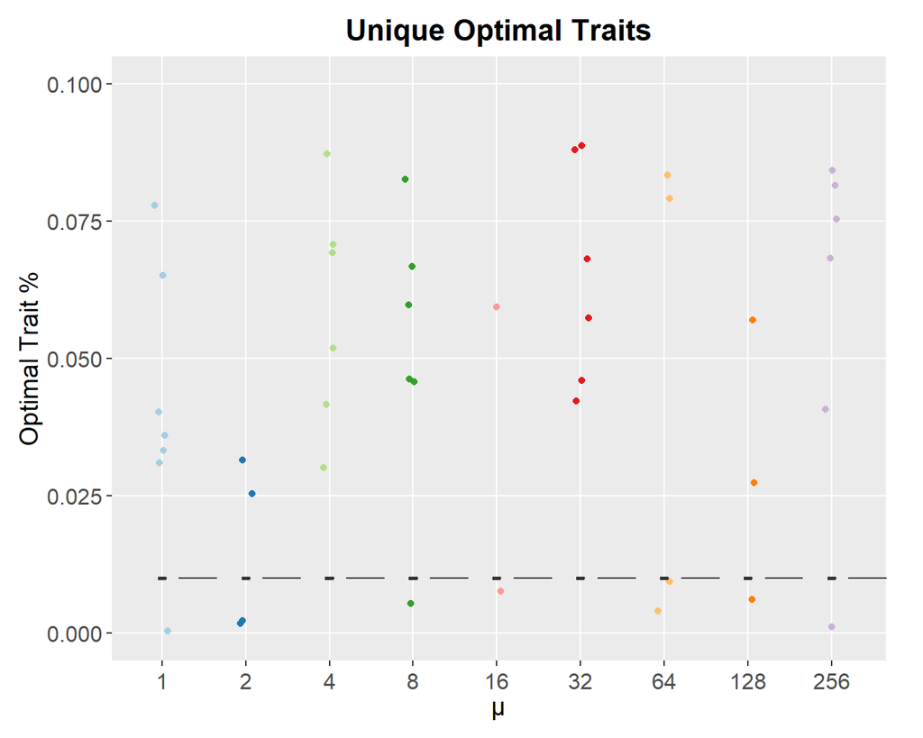

### 2.1.1 Stats Tests

No stats test possible since all values are the same.

# 3 Tournament Selection

Here we explore the impact of different tournament size values on the exploitation diagnostic.

## 3.1 Best Unique Trait Count Found

We look at the best unique optimal trait count found throughout an evolutionary run to see if there is any differences in performances found.

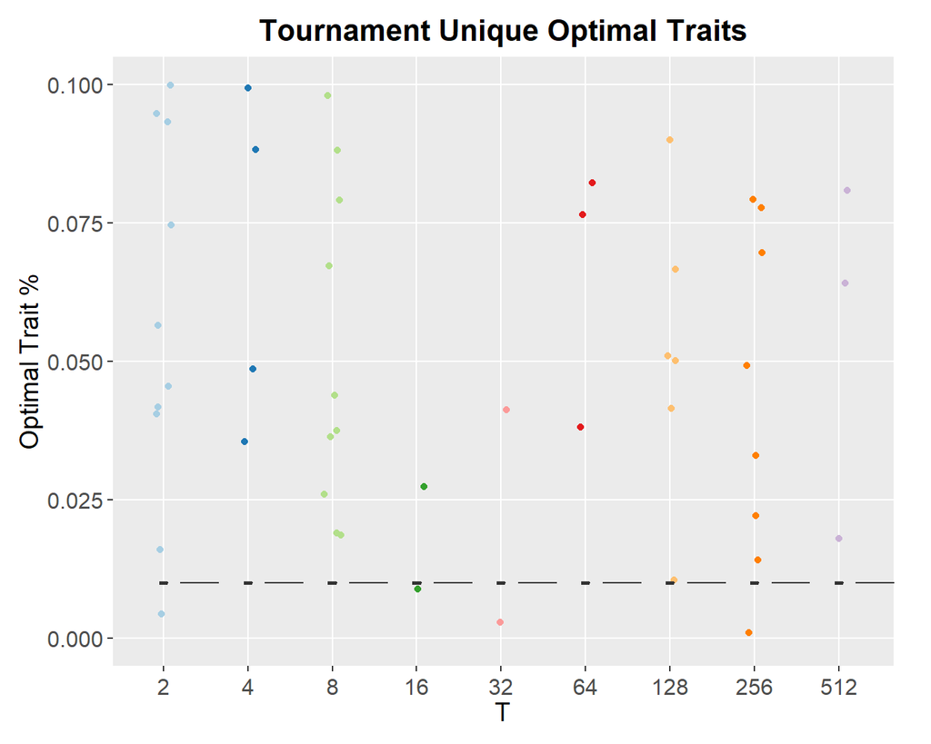

### 3.1.1 Stats Tests

No stats test possible since all values are the same.

# 4 Epsilon Lexicase Selection

Here we explore the impact of different epsilon values on the niching diagnostic.

## 4.1 Best Unique Trait Count Found

We look at the best unique optimal trait count found throughout an evolutionary run to see if there is any differences in performances found.

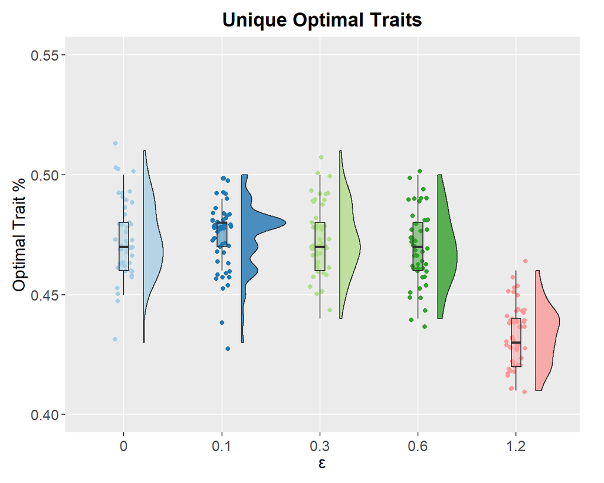

### 4.1.1 Stats Tests

The Kuskal-Wallis test finds evidence that groups do not come from the same distribution.

```r
kruskal.test(val ~ trt, data = df)
```

```
##
##  Kruskal-Wallis rank sum test
##
## data:  val by trt
## Kruskal-Wallis chi-squared = 113.97, df = 4, p-value < 2.2e-16
```

We find evidence of no difference between 0,.1,.3,.6.

```r
pairwise.wilcox.test(x = df$val, g = df$trt, p.adjust.method = "bonferroni", paired = FALSE, conf.int = TRUE, conf.level = .95, alternative = 't')
```

```
##
##  Pairwise comparisons using Wilcoxon rank sum test
##
## data:  df$val and df$trt
##
##     0       0.1     0.3     0.6
## 0.1 1.00    -       -       -
## 0.3 1.00    1.00    -       -
## 0.6 1.00    0.31    1.00    -
## 1.2 1.1e-15 1.3e-15 4.9e-16 4.5e-15
##
## P value adjustment method: bonferroni
```

# 5 Novelty Aggregate

Here we explore the impact of different nearest neighbor values on the exploitation diagnostic.

## 5.1 Best Unique Trait Count Found

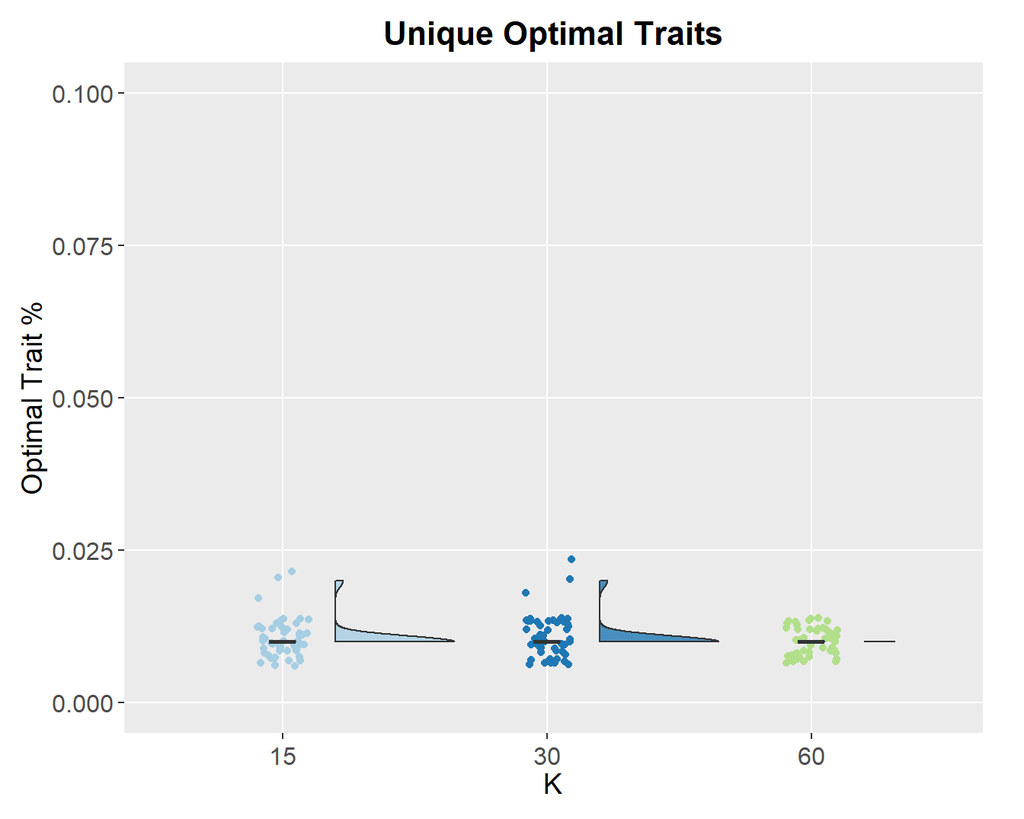

### 5.1.1 Summary Statistics

```r
do.call("rbind", tapply(df$val, df$trt, summary))
```

```
##    Min. 1st Qu. Median   Mean 3rd Qu. Max.
## 15 0.01    0.01   0.01 0.0106    0.01 0.02
## 30 0.01    0.01   0.01 0.0106    0.01 0.02
## 60 0.01    0.01   0.01 0.0100    0.01 0.01
```

### 5.1.2 Stats Tests

```r
kruskal.test(val ~ trt, data = df)
```

```
##
##  Kruskal-Wallis rank sum test
##
## data:  val by trt
## Kruskal-Wallis chi-squared = 3.1042, df = 2, p-value = 0.2118
```

```r
pairwise.wilcox.test(x = df$val, g = df$trt, p.adjust.method = "bonferroni", paired = FALSE, conf.int = TRUE, conf.level = .95, alternative = 'l')
```

```
##
##  Pairwise comparisons using Wilcoxon rank sum test
##
## data:  df$val and df$trt
##
##    15   30
## 30 1.00 -
## 60 0.12 0.12
##
## P value adjustment method: bonferroni
```

# 6 Fitness Sharing

Here we explore the impact of different similarity thresholds on the exploitation diagnostic.

## 6.1 Best Unique Trait Count Found

We look at the best performances found throughout an evolutionary run to see if there is any differences in performances found.

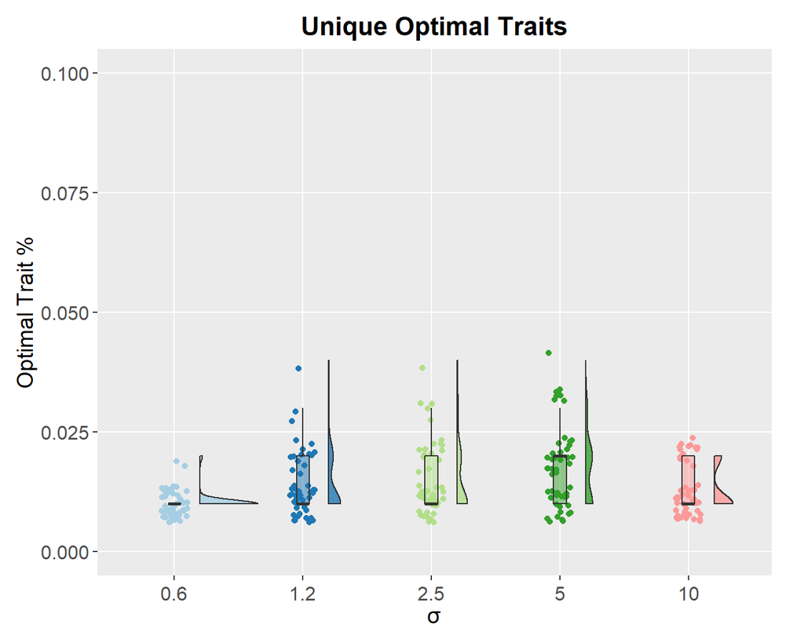

### 6.1.1 Stats Tests

The Kuskal-Wallis test finds evidence that groups do not come from the same distribution.

```r
kruskal.test(val ~ trt, data = df)
```

```
##
##  Kruskal-Wallis rank sum test
##
## data:  val by trt
## Kruskal-Wallis chi-squared = 33.46, df = 4, p-value = 9.617e-07
```

We find evidence that 1.2, 2.5, and 5 have no statictical difference.

```r
pairwise.wilcox.test(x = df$val, g = df$trt, p.adjust.method = "bonferroni", paired = FALSE, conf.int = TRUE, conf.level = .95, alternative = 't')
```

```
##
##  Pairwise comparisons using Wilcoxon rank sum test
##
## data:  df$val and df$trt
##
##     0.6     1.2     2.5     5
## 1.2 0.00271 -       -       -
## 2.5 0.00062 1.00000 -       -
## 5   1.7e-07 0.15339 0.63071 -
## 10  0.01148 1.00000 1.00000 0.01647
##
## P value adjustment method: bonferroni
```

```r
pairwise.wilcox.test(x = df$val, g = df$trt, p.adjust.method = "bonferroni", paired = FALSE, conf.int = TRUE, conf.level = .95, alternative = 'g')
```

```
##
##  Pairwise comparisons using Wilcoxon rank sum test
##
## data:  df$val and df$trt
##
##     0.6     1.2     2.5     5
## 1.2 0.00135 -       -       -
## 2.5 0.00031 1.00000 -       -
## 5   8.7e-08 0.07669 0.31535 -
## 10  0.00574 1.00000 1.00000 1.00000
##
## P value adjustment method: bonferroni
```

```r
pairwise.wilcox.test(x = df$val, g = df$trt, p.adjust.method = "bonferroni", paired = FALSE, conf.int = TRUE, conf.level = .95, alternative = 'l')
```

```
##
##  Pairwise comparisons using Wilcoxon rank sum test
##
## data:  df$val and df$trt
##
##     0.6    1.2    2.5    5
## 1.2 1.0000 -      -      -
## 2.5 1.0000 1.0000 -      -
## 5   1.0000 1.0000 1.0000 -
## 10  1.0000 1.0000 1.0000 0.0082
##
## P value adjustment method: bonferroni
```

# 7 Novelty Euclidean

## 7.1 Best Unique Trait Count Found

As expected, novelty does not do well at this diagnostic.

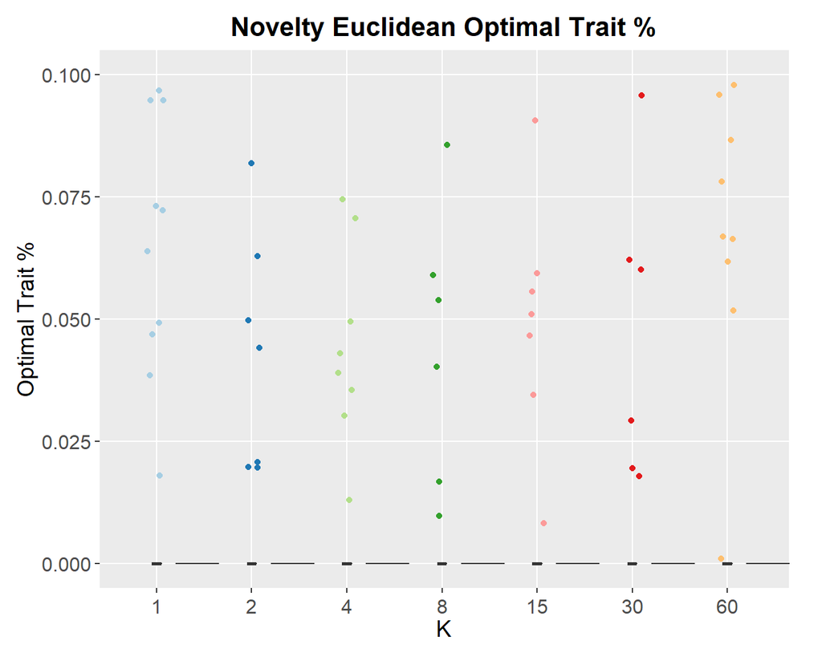

### 7.1.1 Summary Statistics

No stats test possible since all values are the same.